# Decision trees

### Decision trees: supervised, white box, classification, non-parametric method.

Documentation:

- https://en.wikipedia.org/wiki/Sensitivity_and_specificity
- http://scikit-learn.org/stable/modules/generated/sklearn.tree.DecisionTreeClassifier.html
- http://scikit-learn.org/stable/modules/generated/sklearn.model_selection.train_test_split.html
- https://en.wikipedia.org/wiki/Decision_tree_learning
- https://en.wikipedia.org/wiki/ID3_algorithm
- Python Data Science Handbook, Jake VanderPlas
- Introduction to machine learning / Ethem Alpaydin. — 2nd ed
- Introduction to Machine Learning with Python by Andreas C. Müller and Sarah Guido

**ID3 (Iterative Dichotomiser 3)** Basado en la entropia: Quieres maximizar la entropia, que la informacion este lo mas desordenada posible. Se mira el IG Information Gain (la reduccion que se produce en la entropia).  
Entropia: quieres minimizarla, pi=1. El maximo se obtiene cuando todos los pi tienen el mismo valor. Esto quiere decir que las clases son "impuras", los elementos son heterogeneos. Pero tu quieres diferenciar las clases lo maximo posible, que sean homogeneas.

En un caso quieres MIN entropy, en otro MAX information gain.

ID3 and C4.5 by Ross Quinlan

**C4.5** version mejorada: C4.5 lo mismo pero utiliza Normalized Information Gain Ratio y ademas intentara cortar el arbol al final del proceso. Es la version mejorada de ID3. Asi la var DNI que tiene muchas categorias sera penalizada.

**Impurity criteria**  
For categorical responsense:  
-$Entropy = - \sum_{i}^{n} p_i log(p_i) $  
-$ Gini = 1- \sum_{i}^{n} p_i^2 $ Se quiere MIN

For continous responses:  
-Variance

CART var respuesta tanto para numericas como categoricas. Explanatory var de cualquier tipo. BUT just perform binary trees.

https://en.wikipedia.org/wiki/Decision_tree_learning  
https://en.wikipedia.org/wiki/ID3_algorithm  
https://en.wikipedia.org/wiki/C4.5_algorithm

**Classification vs Regression trees.**  
Decision trees where the target variable (or predicted outcome) can take continuous values (typically real numbers) are called regression trees.  
**Classification And Regression Tree (CART)** analysis is an umbrella term used to refer to both of the above procedures, first introduced by Breiman et al. in 1984.

Some techniques, often called ensemble methods, construct more than one decision tree:

Boosted trees Incrementally building an ensemble by training each new instance to emphasize the training instances previously mis-modeled. A typical example is AdaBoost. These can be used for regression-type and classification-type problems.[4][5] Bootstrap aggregated (or bagged) decision trees, an early ensemble method, builds multiple decision trees by repeatedly resampling training data with replacement, and voting the trees for a consensus prediction.[6] A random forest classifier is a specific type of bootstrap aggregating

Features - variables -classes -> there is a single feature called Classification  
Split source set into subsets based on an attribute set. -> Recursive partitioning

Random forests are an example of an ensemble method, meaning that it relies on aggregating the results of an ensemble of simpler estimators

### Limitations:

-Trees can be very non-robust. A small change in the training data can result in a large change in the tree and consequently the final predictions.

-The problem of learning an optimal decision tree is known to be NP-complete under several aspects of optimality and even for simple concepts.Consequently, practical decision-tree learning algorithms are based on heuristics such as the greedy algorithm where locally optimal decisions are made at each node. Such algorithms cannot guarantee to return the globally optimal decision tree.

-Overfitting: Decision-tree learners can create over-complex trees that do not generalize well from the training data.

-For data including categorical variables with different numbers of levels, information gain in decision trees is biased in favor of attributes with more levels.  
-The DecisionTreeRegressor (and all other tree-based regression models) is not able to extrapolate, or make predictions outside of the range of the training data.

**Criteria to avoid overfitting:**  
There are two common strategies to prevent overfitting: stopping the creation of the tree early (also called pre-pruning), or building the tree but then removing or collapsing nodes that contain little information (also called post-pruning or just pruning). Possible criteria for pre-pruning include limiting the maximum depth of the tree, limiting the maximum number of leaves, or requiring a minimum number of points in a node to keep splitting it.  
Do not split examples when Information Gain above a threshold (pre-bounding).

**C4.5 made a number of improvements to ID3.** Some of these are:

-Handling both continuous and discrete attributes  
-In order to handle continuous attributes, C4.5 creates a threshold and then splits the list into those whose attribute value is above the threshold and those that are less than or equal to it.  
-Handling training data with missing attribute values  
-C4.5 allows attribute values to be marked as ? for missing. Missing attribute values are simply not used in gain and entropy calculations.  
-Handling attributes with differing costs.  
-Pruning trees after creation  
-C4.5 goes back through the tree once it's been created and attempts to remove branches that do not help by replacing them with leaf nodes.

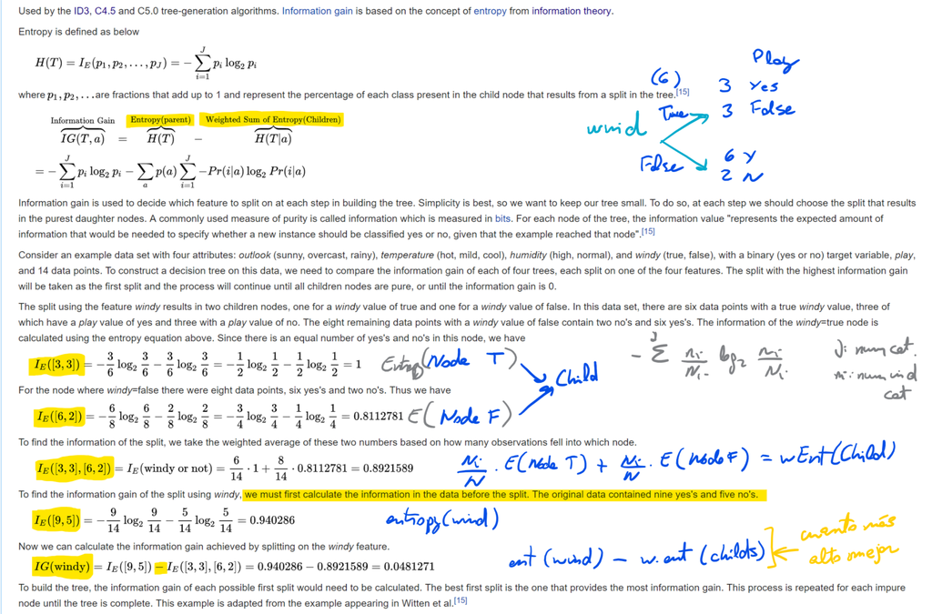

```python
from IPython.display import display, Image, SVG, Math, YouTubeVideo

i = Image(filename ='C:/Users/agusa/Desktop/Min Dades/decision trees/IG.png')
i

# Image(url='https://www.python.org/static/img/python-logo-large.png')
#Image(url='http://jupyter.org/assets/nav_logo.svg')
#eq = Math(r"\int_{-\infty}^\infty f(x) \delta(x - x_0) dx = f(x_0)")
#display(eq)

#%%latex
#\begin{equation}
#\int_{-\infty}^\infty f(x) \delta(x - x_0) dx = f(x_0)
#\end{equation}

#YouTubeVideo('iV2ViNJFZC8')

# &ensp (x2), &nbsp, &emsp (x4)
```

### Scikit-learn

As with other classifiers, **DecisionTreeClassifier** takes as input two arrays: an array X, sparse or dense, of size [n_samples, n_features] holding the training samples, and an array Y of integer values, size [n_samples], holding the class labels for the training samples:  
**Documentacion:** http://scikit-learn.org/stable/modules/generated/sklearn.tree.DecisionTreeClassifier.html

- Is capable of binary classification and multiclass (or multi-way)

Parameters of decision trees:

DecisionTreeClassifier(  
criterion=’gini’,  
splitter=’best’,  
max_depth=None,  
min_samples_split=2,  
min_samples_leaf=1,  
min_weight_fraction_leaf=0.0,  
max_features=None,  
random_state=None,  
max_leaf_nodes=None,  
min_impurity_decrease=0.0,  
min_impurity_split=None,  
class_weight=None,  
presort=False  
)

**Methods for DecisionTreeClassifier**

- Fit: Build a decision tree classifier from the training set (X, y).
- Predict(X): Predict class or regression value for X.
- Predict_proba(X): Predict class probabilities of the input samples X. The predicted class probability is the fraction of samples of the same class in a leaf.

All decision trees use np.float32 arrays internally. If training data is not in this format, a copy of the dataset will be made.

```python
%matplotlib inline
import numpy as np
from sklearn import tree
X = [[0, 0], [1, 1]]
Y = [0, 1]
clf = tree.DecisionTreeClassifier()
clf = clf.fit(X, Y)
clf
```

```
DecisionTreeClassifier(class_weight=None, criterion='gini', max_depth=None,
            max_features=None, max_leaf_nodes=None,
            min_impurity_decrease=0.0, min_impurity_split=None,
            min_samples_leaf=1, min_samples_split=2,
            min_weight_fraction_leaf=0.0, presort=False, random_state=None,
            splitter='best')
```

After being fitted, the model can then be used to predict the class of samples:

```python
clf.predict([[2., 2.]])
```

```
array([1])
```

Alternatively, the probability of each class can be predicted, which is the fraction of training samples of the same class in a leaf. Classification problem two classes: Miramos si la prob es mayor o menor de 0.5 para asignar un valor!

```python
clf.predict_proba([[2., 2.]])
```

```
array([[0., 1.]])
```

```python
clf.decision_path([[2., 2.]])
```

```
<1x3 sparse matrix of type '<class 'numpy.int64'>'
	with 2 stored elements in Compressed Sparse Row format>
```

Utilizando los datos del iris dataset. iris.data y iris.target son matrices numpy!

```python
from sklearn.datasets import load_iris
from sklearn import tree
iris = load_iris()
clf = tree.DecisionTreeClassifier() # parametros por defecto
clf.fit(iris.data, iris.target)
```

```
DecisionTreeClassifier(class_weight=None, criterion='gini', max_depth=None,
            max_features=None, max_leaf_nodes=None,
            min_impurity_decrease=0.0, min_impurity_split=None,
            min_samples_leaf=1, min_samples_split=2,
            min_weight_fraction_leaf=0.0, presort=False, random_state=None,
            splitter='best')
```

```python
iris.keys()
print(iris['DESCR'][:980] + "\n...")
iris["target_names"]
iris["feature_names"]
iris['data'].shape  # n_samples = 150 ; n_features= 4 (1 es la target variable)
iris["data"][:5]
iris["target"]
# sepal width and length
# petal width and length
```

```
Iris Plants Database
====================

Notes
-----
Data Set Characteristics:
    :Number of Instances: 150 (50 in each of three classes)
    :Number of Attributes: 4 numeric, predictive attributes and the class
    :Attribute Information:
        - sepal length in cm
        - sepal width in cm
        - petal length in cm
        - petal width in cm
        - class:
                - Iris-Setosa
                - Iris-Versicolour
                - Iris-Virginica
    :Summary Statistics:

    ============== ==== ==== ======= ===== ====================
                    Min  Max   Mean    SD   Class Correlation
    ============== ==== ==== ======= ===== ====================
    sepal length:   4.3  7.9   5.84   0.83    0.7826
    sepal width:    2.0  4.4   3.05   0.43   -0.4194
    petal length:   1.0  6.9   3.76   1.76    0.9490  (high!)
    petal width:    0.1  2.5   1.20  0.76     0.9565  (high!)
    ============== ==== ==== ======= ===== ===================
...
```

```
array([0, 0, 0, 0, 0, 0, 0, 0, 0, 0, 0, 0, 0, 0, 0, 0, 0, 0, 0, 0, 0, 0,
       0, 0, 0, 0, 0, 0, 0, 0, 0, 0, 0, 0, 0, 0, 0, 0, 0, 0, 0, 0, 0, 0,
       0, 0, 0, 0, 0, 0, 1, 1, 1, 1, 1, 1, 1, 1, 1, 1, 1, 1, 1, 1, 1, 1,
       1, 1, 1, 1, 1, 1, 1, 1, 1, 1, 1, 1, 1, 1, 1, 1, 1, 1, 1, 1, 1, 1,
       1, 1, 1, 1, 1, 1, 1, 1, 1, 1, 1, 1, 2, 2, 2, 2, 2, 2, 2, 2, 2, 2,
       2, 2, 2, 2, 2, 2, 2, 2, 2, 2, 2, 2, 2, 2, 2, 2, 2, 2, 2, 2, 2, 2,
       2, 2, 2, 2, 2, 2, 2, 2, 2, 2, 2, 2, 2, 2, 2, 2, 2, 2])
```

```
[0.01333333 0.01333333 0.55072262 0.42261071]
```

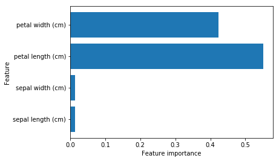

```python
import matplotlib.pyplot as plt

def plot_feature_importances(model):
    n_features = iris["data"].shape[1]
    plt.barh(range(n_features), model.feature_importances_, align='center')
    plt.yticks(np.arange(n_features), iris.feature_names)
    plt.xlabel("Feature importance")
    plt.ylabel("Feature")

print(clf.feature_importances_)
plot_feature_importances(clf)

#clf = tree.DecisionTreeClassifier() # parametros por defecto
#clf.fit(iris.data, iris.target)
```

```python
import graphviz
dot_data = tree.export_graphviz(clf, out_file=None)
graph = graphviz.Source(dot_data)
graph.render("iris")
```

```
'iris.pdf'
```

```python
dot_data = tree.export_graphviz(clf, out_file=None,
                         feature_names=iris.feature_names,
                         class_names=iris.target_names,
                         filled=True, rounded=True,
                         special_characters=True)
graph = graphviz.Source(dot_data)
#graph
```

```python
from sklearn.tree import DecisionTreeClassifier

from sklearn.datasets import load_breast_cancer
cancer = load_breast_cancer()
print("nsamples and nfeatures",cancer["data"].shape,"\n")
print(cancer.keys(),"\n")
print("clases de la variable respuesta:",cancer["target_names"])
cancer["feature_names"]

# no todos los elementos se printan al ejecutarlos?
# tienes que poner print para verlos
```

```
nsamples and nfeatures (569, 30)

dict_keys(['data', 'target', 'target_names', 'DESCR', 'feature_names'])

clases de la variable respuesta: ['malignant' 'benign']
```

```
array(['mean radius', 'mean texture', 'mean perimeter', 'mean area',
       'mean smoothness', 'mean compactness', 'mean concavity',
       'mean concave points', 'mean symmetry', 'mean fractal dimension',
       'radius error', 'texture error', 'perimeter error', 'area error',
       'smoothness error', 'compactness error', 'concavity error',
       'concave points error', 'symmetry error',
       'fractal dimension error', 'worst radius', 'worst texture',
       'worst perimeter', 'worst area', 'worst smoothness',
       'worst compactness', 'worst concavity', 'worst concave points',
       'worst symmetry', 'worst fractal dimension'], dtype='<U23')
```

One part of the data is used to build our machine learning model, and is called the **training data or training set**. The rest of the data will be used to assess how well the model works; this is called the **test data, test set, or hold-out set**.

scikit-learn contains a function that shuffles the dataset and splits it for you: **the train_test_split function**. This function **extracts 75% of the rows in the data as the training set**, together with the corresponding labels for this data. The **remaining 25% of the data, together with the remaining labels, is declared as the test set**.

- X representa la matriz de datos (two dimensional array).
- y representa el vector de la variable respuesta.

```python
from sklearn.model_selection import train_test_split
# cancer.data, cancer.target metodos para extraer cancer["data"] etc

X_train, X_test, y_train, y_test = train_test_split(cancer.data, cancer.target, stratify=cancer.target, random_state=42)

print("X_train shape: {}".format(X_train.shape))
print("y_train shape: {}".format(y_train.shape))
print("X_test shape: {}".format(X_test.shape))
print("y_test shape: {}".format(y_test.shape),"\n")

# X_train, X_test, y_train, y_test un total de 4 conjuntos!

print(143/(426+143),"\n")

tree = DecisionTreeClassifier(random_state=0)
tree.fit(X_train, y_train)
tree.score(X_train, y_train)
print("Accuracy on training set: {:.3f}".format(tree.score(X_train, y_train)))
print("Accuracy on test set: {:.3f}".format(tree.score(X_test, y_test)))
```

```
X_train shape: (426, 30)
y_train shape: (426,)
X_test shape: (143, 30)
y_test shape: (143,)

0.2513181019332162

Accuracy on training set: 1.000
Accuracy on test set: 0.937
```

**Argumentos para evitar overfitting:**  
-**Pre-prunning**: max_depth, max_leaf_nodes, or min_samples_leaf.  
max_depth is the number of test (questions) you ask to the data.

### Ensemble methods: random forests and gradient boosted decision trees

The main downside of decision trees is that even with the use of pre-pruning, they tend to overfit and provide poor generalization performance. Therefore, in most applications, the ensemble methods we discuss next are usually used in place of a single decision tree.  
**Ensembles are methods that combine multiple machine learning models to create more powerful models.**  
Both of which use decision trees as their building blocks: **random forests and gradient boosted decision trees.**  
*DecicionTree vs RandomForest*, Classifier, and Regressor.

-> Decision trees son mejores cuando queremos una representacion de las reglas que se utilizan para clasificar los datos, ya que con ensemble methods al combinar varios arboles no se puede.

### Building random forests

-To build a random forest model, you need to decide on the number of trees to build (the **n_estimators** parameter of RandomForestRegressor or RandomForestClassifier).

-The number of features (subset) that are selected randomly is controlled by the **max_features** parameter. This selection of a subset of features is repeated separately in each node, so that each node in a tree can make a decision using a different subset of the features.  
*A low max_features means that the trees in the random forest will be quite different*, and that each tree might need to be very deep in order to fit the data well.

-If you are using a multi-core processor (as nearly all modern computers do), you can use the **n_jobs** parameter to adjust the number of cores to use. *Using more CPU cores will result in linear speed-ups (using two cores, the training of the random forest will be twice as fast)*, but specifying n_jobs larger than the number of cores will not help. You can set n_jobs=-1 to use all the cores in your computer.

-The more trees there are in the forest, the more robust it will be against the choice of random state. If you want to have reproducible results, it is important to fix the **random_state**.

-There are the previous *pre-prunning options* like **max_depth, max_leaf_nodes, or min_samples_leaf**:  
As described earlier, max_features determines how random each tree is, and a smaller max_features reduces overfitting. In general, it’s a good rule of thumb to use the default values: **max_features=sqrt(n_features) for classification and max_fea tures=log2(n_features) for regression**. Adding max_features or max_leaf_nodes might sometimes improve performance. It can also drastically reduce space and time requirements for training and prediction.

### Gradient boosted regression trees (gradient boosting machines)

- Can be used for classification and regression.

There is no randomization in gradient boosted regression trees; instead, strong pre-pruning is used. Gradient boosted trees often use very shallow trees, of depth one to five, which makes the model smaller in terms of memory and makes predictions faster.  
The main idea behind gradient boosting is to combine many simple models (in this context known as weak learners), like shallow trees. Each tree can only provide good predictions on part of the data, and so more and more trees are added to iteratively improve performance.

-Apart from the **pre-pruning** and the **number of trees in the ensemble, n_estimators** parameter, another important parameter of gradient boosting is the **learning_rate**, *which controls how strongly each tree tries to correct the mistakes of the previous trees*.

-The two most important parameters are interconnected, as a *lower* learning_rate means that more trees are needed to build a model of similar complexity. In contrast to random forests, where a higher n_esti mators value is always better, *increasing n_estimators in gradient boosting leads to a more complex model*, which may lead to overfitting.

Another important parameter is **max_depth (or alternatively max_leaf_nodes)**, to reduce the complexity of each tree. Usually max_depth is set very low for gradient boosted models, often not deeper than five splits.

- By default, 100 trees of maximum depth 3 and a learning rate of 0.1 are used.
- xgboost package de Python suele ser mejor que la implementacion que hay en scikit-learn.

### Limitations

-Their main drawback is that they require careful tuning of the parameters and may take a long time to train.

.

```python
#import rpy2 as robj
#r.

import pandas as pd
#dades = pd.read_csv("C:/Users/agusa/Desktop/Min Dades/Treballs/MyData.csv", names=["AGE","WEIGHT","HEIGHT","LOWLEG","ARM","WAIST","THIGH","TIMEBLOOD","ENERGY","CARBOHYDRATE","FAT","CHOLESTEROL","SEX","ETNIA","RENTA","PHYSICALCOND","SLEEPPROBLEM","TIRED","APPETITE","TRANSPORT","PHYSICALACT","LEISURE"],sep=",",quotechar='"')
dades = pd.read_csv("C:/Users/agusa/Desktop/Min Dades/Treballs/credscoClean.csv",sep=";")
dades.head()
```

|  | Dictamen | Antiguedad.Trabajo | Vivienda | Plazo | Edad | Estado.civil | Registros | Tipo.trabajo | Gastos | Ingresos | Patrimonio | Cargas.patrimoniales | Importe.solicitado | Precio.del.bien.financiado | Estalvi | RatiFin |
| --- | --- | --- | --- | --- | --- | --- | --- | --- | --- | --- | --- | --- | --- | --- | --- | --- |
| 0 | positiu | 9 | lloguer | 60 | 30 | casat | reg_no | autonom | 73 | 129 | 0 | 0 | 800 | 846 | 4.2 | 945.626.477.541.371 |
| 1 | positiu | 17 | lloguer | 60 | 58 | vidu | reg_no | fixe | 48 | 131 | 0 | 0 | 1000 | 1658 | 4.98 | 60.313.630.880.579 |
| 2 | negatiu | 10 | escriptura | 36 | 46 | casat | reg_si | autonom | 90 | 200 | 3000 | 0 | 2000 | 2985 | 1.98 | 67.001.675.041.876 |
| 3 | positiu | 0 | lloguer | 60 | 24 | solter | reg_no | fixe | 63 | 182 | 2500 | 0 | 900 | 1325 | 793.333.333.333.333 | 679.245.283.018.868 |
| 4 | positiu | 0 | lloguer | 36 | 26 | solter | reg_no | fixe | 46 | 107 | 0 | 0 | 310 | 910 | 708.387.096.774.194 | 340.659.340.659.341 |

```python
#print(dades)
#dades["Vivienda"][:10]

import numpy as np
from sklearn import tree
X = dades[["Plazo","Patrimonio","Edad","Ingresos","Gastos"]]
Y = dades[["Vivienda"]]
clf = tree.DecisionTreeClassifier(
    max_depth=3,
min_samples_split=20,
min_samples_leaf=20)

clf = clf.fit(X, Y)
clf
#clf.n_features_
```

```
DecisionTreeClassifier(class_weight=None, criterion='gini', max_depth=3,
            max_features=None, max_leaf_nodes=None,
            min_impurity_decrease=0.0, min_impurity_split=None,
            min_samples_leaf=20, min_samples_split=20,
            min_weight_fraction_leaf=0.0, presort=False, random_state=None,
            splitter='best')
```

```python
clf.tree_.node_count
feature = clf.tree_.feature
threshold = clf.tree_.threshold
feature
```

```
array([ 1,  4,  3, -2, -2,  4, -2, -2,  2,  4, -2, -2,  1, -2, -2],
      dtype=int64)
```

```python
Y1 = np.array(Y)
X1 = np.array(X)
clf = clf.fit(X1, Y1)
X1
clf
```

[output not shown]

```python
clf.feature_importances_ # Plazo no interviene?
```

```
array([0.        , 0.68547373, 0.03087802, 0.01765511, 0.26599315])
```

```python
print(clf.decision_path([[0, 5346,37,130,55]])) # se han cogido las medias, excepto en Plazo, no hace falta?
# matriz: shape = [n_samples, n_nodes], 2a columna dice los nodos por los que pasa. Llega hasta el 14 -> y3, escriptura
```

```
  (0, 0)	1
  (0, 8)	1
  (0, 12)	1
  (0, 14)	1
```

```python
print(clf.predict([[0, 5346,37,130,55]]))
```

```
['escriptura']
```

```python
# objetos list
nombres = ["Plazo","Patrimonio","Edad","Ingresos","Gastos"]
target = ["altres viv","contr_privat","escriptura","ignora_cont","lloguer","pares","VivUnkown"]

# Falta saber como estan ordenadas las clases de Vivienda!!
```

```python
import graphviz
dot_data = tree.export_graphviz(clf, out_file=None)
graph = graphviz.Source(dot_data)
graph.render("credsco")

dot_data = tree.export_graphviz(clf, out_file=None,
                         feature_names=["Plazo","Patrimonio","Edad","Ingresos","Gastos"],
                         class_names=True,
                         filled=True, rounded=True,
                         special_characters=True ,
                         label="all",
                         node_ids=True)
graph = graphviz.Source(dot_data)
graph
```

[figure not shown]

```python
dd = pd.read_csv("C:/Users/agusa/Desktop/Min Dades/Treballs/MyData.csv",sep=",") # encoding= utf-8
dd.head()
```

|  | AGE | WEIGHT | HEIGHT | LOWLEG | ARM | WAIST | THIGH | TIMEBLOOD | ENERGY | CARBOHYDRATE | ... | SEX | ETNIA | RENTA | PHYSICALCOND | SLEEPPROBLEM | TIRED | APPETITE | TRANSPORT | PHYSICALACT | LEISURE |
| --- | --- | --- | --- | --- | --- | --- | --- | --- | --- | --- | --- | --- | --- | --- | --- | --- | --- | --- | --- | --- | --- |
| 0 | 85 | 78.231139 | 162.73026 | 38.236821 | 32.476 | 98.522676 | 52.554560 | 646.974263 | 1084.244391 | 145.22494 | ... | FEMALE | Non-Hispanic White | Baix | No contestats | No contestats | No contestats | No contestats | No | Walk during the day | Normal |
| 1 | 44 | 75.200000 | 156.00000 | 36.600000 | 35.800 | 96.000000 | 53.700000 | 827.000000 | 1458.000000 | 233.73000 | ... | FEMALE | Non-Hispanic Black | Alt | Good | No | No | No | Yes | Sit during the day | Normal |
| 2 | 70 | 69.500000 | 167.60000 | 35.600000 | 31.200 | 96.500000 | 48.000000 | 730.000000 | 2168.000000 | 269.93000 | ... | MALE | Non-Hispanic White | Alt | Very good | No | No | No | No | Walk during the day | Normal |
| 3 | 73 | 101.900000 | 182.40000 | 42.600000 | 33.000 | 117.100000 | 50.500000 | 844.000000 | 2159.000000 | 299.80000 | ... | MALE | Non-Hispanic White | Mitjà | Good | No | No | No | Yes | Lift light load/Climb stairs or hill | Poc |
| 4 | 18 | 73.900000 | 158.40000 | 40.200000 | 31.800 | 84.000000 | 51.070719 | 749.000000 | 980.000000 | 134.28000 | ... | FEMALE | Other Hispanic | Alt | Very good | No | No | No | Yes | Walk during the day | Normal |

5 rows × 22 columns

```python
# dades
import numpy as np
from sklearn import tree
X = dd[["AGE","WEIGHT","HEIGHT","TIMEBLOOD"]] # solo para variables numericas; "TRANSPORT" -> could not convert string to float!
Y = dd[["ENERGY"]]
clf = tree.DecisionTreeRegressor(
    max_depth=3,
min_samples_leaf=30,
random_state=1997
)

clf = clf.fit(X, Y)
clf
```

```
DecisionTreeRegressor(criterion='mse', max_depth=3, max_features=None,
           max_leaf_nodes=None, min_impurity_decrease=0.0,
           min_impurity_split=None, min_samples_leaf=30,
           min_samples_split=2, min_weight_fraction_leaf=0.0,
           presort=False, random_state=1997, splitter='best')
```

```python
feature = clf.tree_.feature
threshold = clf.tree_.threshold
```

```python
clf.tree_.node_count
```

```
15
```

```python
# objetos list
nombres = ["AGE","WEIGHT","HEIGHT","TIMEBLOOD"]
#target = []
# Falta saber como estan ordenadas las clases de Vivienda!!
```

```python
import graphviz
dot_data = tree.export_graphviz(clf, out_file=None)
graph = graphviz.Source(dot_data)
graph.render("credsco")

dot_data = tree.export_graphviz(clf, out_file=None,
                         feature_names=nombres,
                         class_names=True,
                         filled=True, rounded=True,
                         special_characters=True ,
                         label="all",
                         node_ids=True)
graph = graphviz.Source(dot_data)
graph
```

[figure not shown]